# Atividade 1

Author

Milena Paz Freitas

## Questão 1

**a. Construa a matriz `minhaMat.`**

```r
minhaMat<- matrix(c(6,112,5,545,34,113, 9, 546,923, 114, 34,
  547,5 ,115 ,76 ,548 ,0 ,116 ,2 ,549), byrow=T,ncol=4)
```

**b. Obtenha a média de cada linha.**

```r
rowMeans(minhaMat)
```

```
[1] 167.00 175.50 404.50 186.00 166.75
```

```r
#alternativamente:
#apply(minhaMat,1,mean)
```

**c. Obtenha a média de cada coluna.**

```r
colMeans(minhaMat)
```

```
[1] 193.6 114.0  25.2 547.0
```

```r
#alternativamente:
#apply(minhaMat,2,mean)
```

**d. Ordene as colunas em ordem ascendente.**

```r
minhaMat <- apply(minhaMat, 2,sort)
```

**e. Use a função apply para executar a operação módulo da divisão por 10 em cada elemento da matriz (A nova matriz contém o resto da divisão por 10).**

```r
apply(minhaMat,c(1,2),"%%",10)
```

```
     [,1] [,2] [,3] [,4]
[1,]    0    2    2    5
[2,]    5    3    5    6
[3,]    6    4    9    7
[4,]    4    5    4    8
[5,]    3    6    6    9
```

## Questão 2

**a. Use três funções da família apply para o obter o mínimo de cada coluna do conjunto de dados. Armazene cada resultado em um objeto separado(`l`, `s` e `m`) e mostre suas saídas.**

```r
#lapply
(l<-lapply(mtcars,min))
```

```
$mpg
[1] 10.4

$cyl
[1] 4

$disp
[1] 71.1

$hp
[1] 52

$drat
[1] 2.76

$wt
[1] 1.513

$qsec
[1] 14.5

$vs
[1] 0

$am
[1] 0

$gear
[1] 3

$carb
[1] 1
```

```r
#sapply
(s<-sapply(mtcars,min))
```

```
   mpg    cyl   disp     hp   drat     wt   qsec     vs     am   gear   carb
10.400  4.000 71.100 52.000  2.760  1.513 14.500  0.000  0.000  3.000  1.000
```

```r
#mapply
(m<-mapply(mtcars,FUN=min))
```

```
   mpg    cyl   disp     hp   drat     wt   qsec     vs     am   gear   carb
10.400  4.000 71.100 52.000  2.760  1.513 14.500  0.000  0.000  3.000  1.000
```

**b. Coloque os três objetos `l`, `s` e `m` na lista `lista.objetos`.**

```r
lista.objetos <- list(l=l,s=s,m=m)
```

**c. Use uma função apply adequada para obter a classe de cada um dos três elementos da lista `lista.objetos`.**

```r
classes <- sapply(lista.objetos, FUN=class)
```

**d. Qual a classe da saída de cada uma das três funções usadas no exercício?**

```r
classes
```

```
        l         s         m
   "list" "numeric" "numeric"
```

**e. Repita o exercício usando estruturas de controle. Compare o tempo entre as duas abordagens (Estruturas de controle e família apply)**

```r
f<- numeric(0)
## Tempo de execução com família apply:
inicio <- Sys.time()
a<-apply(mtcars,2,min)
class(a)
```

```
[1] "numeric"
```

```r
tempo.apply<-Sys.time() - inicio
## Tempo de execução com estruturas de controle:
inicio <- Sys.time()
for(i in 1:11){
  f<-append(f,min(mtcars[,i]))
}
class(f)
```

```
[1] "numeric"
```

```r
(Sys.time() - inicio) - tempo.apply
```

```
Time difference of 0.001815796 secs
```

## Questão 3

**a. Use a função mapply para obter uma lista de 10 elementos. O primeiro elemento da lista é uma sequência de 10 caracteres “A”; a segunda, 9 caracteres “F”, que seguem alternando-se até o último elemento o qualpossui um único caractere.**

```r
inicio<- Sys.time()
mapply(x=c(10:1),y=c("A","F"),FUN=function(x,y){
  list(rep(y,x))
})
```

```
[[1]]
 [1] "A" "A" "A" "A" "A" "A" "A" "A" "A" "A"

[[2]]
[1] "F" "F" "F" "F" "F" "F" "F" "F" "F"

[[3]]
[1] "A" "A" "A" "A" "A" "A" "A" "A"

[[4]]
[1] "F" "F" "F" "F" "F" "F" "F"

[[5]]
[1] "A" "A" "A" "A" "A" "A"

[[6]]
[1] "F" "F" "F" "F" "F"

[[7]]
[1] "A" "A" "A" "A"

[[8]]
[1] "F" "F" "F"

[[9]]
[1] "A" "A"

[[10]]
[1] "F"
```

```r
tempo.apply <- Sys.time() - inicio
```

**b. Ajuste a função para obter a numeração adequada de cada elemento dalista. Dica: argumento `USE.NAMES`**

```r
x=c(10:1)
names(x)<- 10:1
y=c("A","F")
mapply(x,y,FUN=function(x,y){
  list(rep(y,x))
},USE.NAMES = T)
```

```
$`10`
 [1] "A" "A" "A" "A" "A" "A" "A" "A" "A" "A"

$`9`
[1] "F" "F" "F" "F" "F" "F" "F" "F" "F"

$`8`
[1] "A" "A" "A" "A" "A" "A" "A" "A"

$`7`
[1] "F" "F" "F" "F" "F" "F" "F"

$`6`
[1] "A" "A" "A" "A" "A" "A"

$`5`
[1] "F" "F" "F" "F" "F"

$`4`
[1] "A" "A" "A" "A"

$`3`
[1] "F" "F" "F"

$`2`
[1] "A" "A"

$`1`
[1] "F"
```

**c. Repita o exercício usando estruturas de controle. Compare o tempo entre as duas abordagens (Estruturas de controle e família apply).**

```r
#estrutura de controle
lista <- list()
inicio <- Sys.time()
for(i in 10:1){
  if(i%%2==0)
    lista[[i]] <- rep("F",times=i)
  else
    lista[[i]] <- rep("A",times=i)
}
lista
```

```
[[1]]
[1] "A"

[[2]]
[1] "F" "F"

[[3]]
[1] "A" "A" "A"

[[4]]
[1] "F" "F" "F" "F"

[[5]]
[1] "A" "A" "A" "A" "A"

[[6]]
[1] "F" "F" "F" "F" "F" "F"

[[7]]
[1] "A" "A" "A" "A" "A" "A" "A"

[[8]]
[1] "F" "F" "F" "F" "F" "F" "F" "F"

[[9]]
[1] "A" "A" "A" "A" "A" "A" "A" "A" "A"

[[10]]
 [1] "F" "F" "F" "F" "F" "F" "F" "F" "F" "F"
```

```r
(Sys.time() - inicio) - tempo.apply
```

```
Time difference of 0.002341032 secs
```

## Questão 4

**a. Use uma função apply apropriada para obter a soma de homens e mulheres à bordo.**

```r
inicio <- Sys.time()
apply(Titanic,2,sum)
```

```
  Male Female
  1731    470
```

```r
tempo.apply <- Sys.time() - inicio
```

**b. Construa uma tabela com a soma de sobreviventes pela variável `Sex`**

```r
inicio <- Sys.time()
apply(Titanic,c(2,4),sum)
```

```
        Survived
Sex        No Yes
  Male   1364 367
  Female  126 344
```

```r
tempo.apply <- tempo.apply + (Sys.time() - inicio)
```

**c. Obtenha uma tabela com a quantidade de passageiros pelas variáveis `Sex` e `Age`.**

```r
inicio <- Sys.time()
apply(Titanic,c(2,3),sum)
```

```
        Age
Sex      Child Adult
  Male      64  1667
  Female    45   425
```

```r
tempo.apply <- tempo.apply + (Sys.time() - inicio)
```

**d. Repita o exercício usando estruturas de controle. Compare o tempo entre as duas abordagens (Estruturas de controle e família apply).**

```r
inicio <- Sys.time()
t<-numeric(2)
names(t)<- c("Male","Female")
for(sx in 1:2) t[sx]<- sum(Titanic[1:4,sx,1:2,1:2])
t
```

```
  Male Female
  1731    470
```

```r
t<-matrix(nrow=2,ncol=2)
colnames(t)<- c("No","Yes")
rownames(t)<- c("Male","Female")
for(sx in 1:2){
  for(v in 1:2)
    t[sx,v]<- sum(Titanic[1:4,sx,1:2,v])
}
t
```

```
         No Yes
Male   1364 367
Female  126 344
```

```r
t<-matrix(nrow=2,ncol=2)
colnames(t)<- c("Child","Adult")
rownames(t)<- c("Male","Female")
for(sx in 1:2){
  for(i in 1:2)
    t[sx,i]<- sum(Titanic[1:4,sx,i,1:2])
}
t
```

```
       Child Adult
Male      64  1667
Female    45   425
```

```r
(Sys.time() - inicio) - tempo.apply
```

```
Time difference of 0.01184773 secs
```

## Questão 5

**a. Crie uma lista de quatro matrizes e denomine-a `lista.obj`.**

```r
primeira <- matrix(38:66, 3)
segunda <- matrix(56:91, 3)
terceira <- matrix(82:145, 3)
quarta <- matrix(46:93, 5)
lista.obj<-list(primeira, segunda, terceira,
quarta)
```

**b. Extraia a segunda coluna de cada matriz dessa lista de matrizes.**

```r
inicio <- Sys.time()
lapply(lista.obj,FUN= function(x) x[,2] )
```

```
[[1]]
[1] 41 42 43

[[2]]
[1] 59 60 61

[[3]]
[1] 85 86 87

[[4]]
[1] 51 52 53 54 55
```

```r
tempo.apply<-Sys.time() - inicio
```

**c. Extraia a terceira linha de cada matriz dessa lista de matrizes.**

```r
inicio <- Sys.time()
lapply(lista.obj, FUN= function(x) x[3,])
```

```
[[1]]
 [1] 40 43 46 49 52 55 58 61 64 38

[[2]]
 [1] 58 61 64 67 70 73 76 79 82 85 88 91

[[3]]
 [1]  84  87  90  93  96  99 102 105 108 111 114 117 120 123 126 129 132 135 138
[20] 141 144  83

[[4]]
 [1] 48 53 58 63 68 73 78 83 88 93
```

```r
tempo.apply<- tempo.apply + (Sys.time() - inicio)
```

**d. Repita o exercício usando estruturas de controle. Compare o tempo entre as duas abordagens (Estruturas de controle e família apply)**

```r
inicio <- Sys.time()
for(i in 1:4){
  print(lista.obj[[i]][,2])
}
```

```
[1] 41 42 43
[1] 59 60 61
[1] 85 86 87
[1] 51 52 53 54 55
```

```r
for(i in 1:4){
  print(lista.obj[[i]][3,])
}
```

```
 [1] 40 43 46 49 52 55 58 61 64 38
 [1] 58 61 64 67 70 73 76 79 82 85 88 91
 [1]  84  87  90  93  96  99 102 105 108 111 114 117 120 123 126 129 132 135 138
[20] 141 144  83
 [1] 48 53 58 63 68 73 78 83 88 93
```

```r
(Sys.time() - inicio)-tempo.apply
```

```
Time difference of 0.001346827 secs
```

## Questão 6

**a. Obtenha um box-plot de cada variável quantitativa do conjunto de dados `iris`, estratificada pela variável `Species`.**

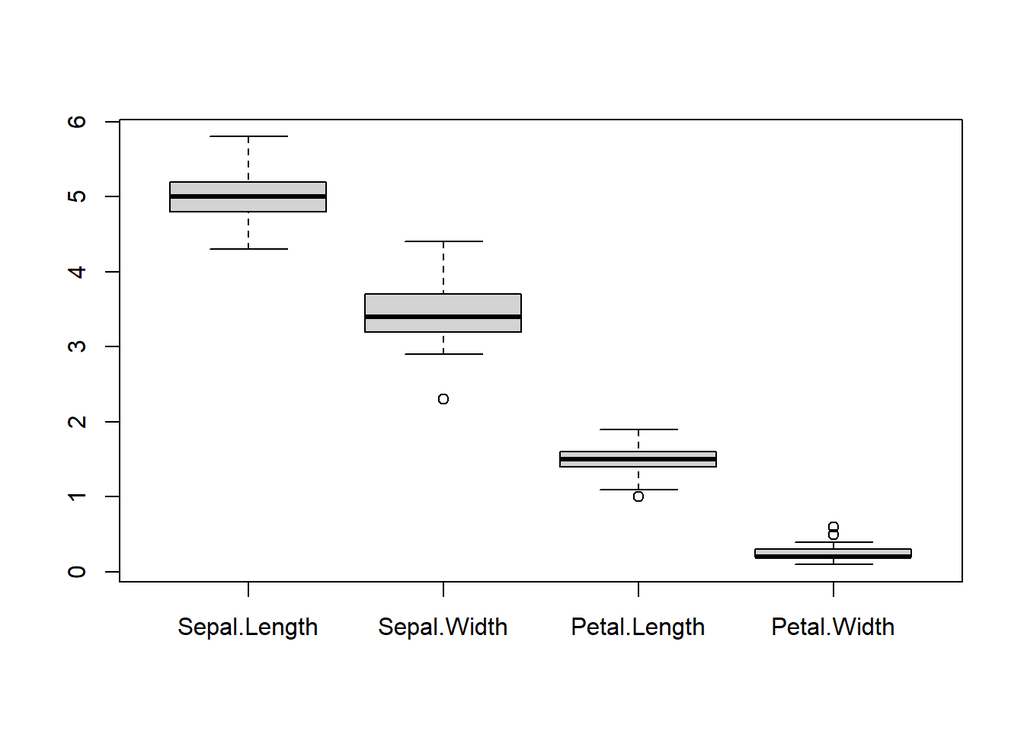

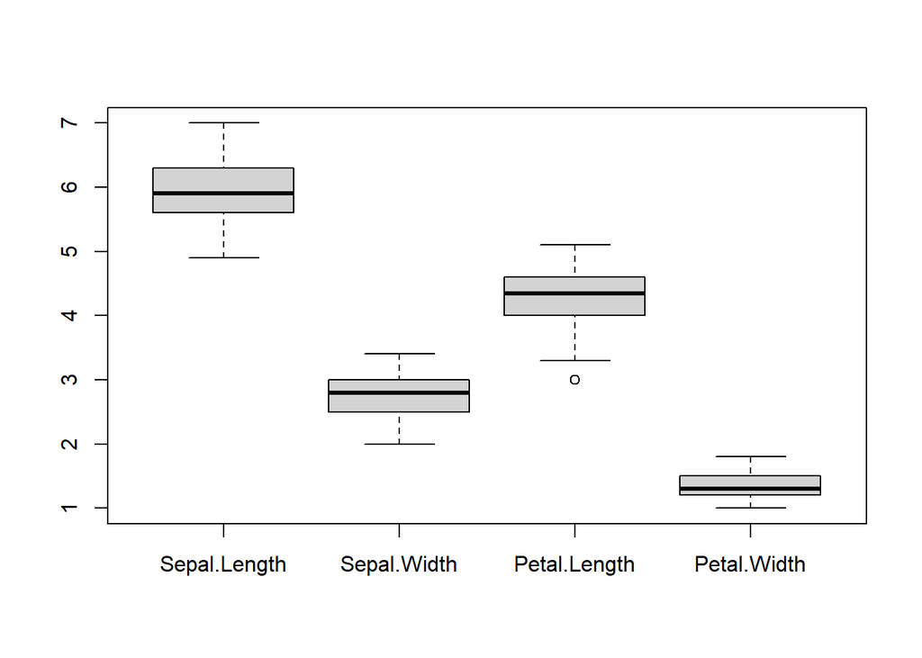

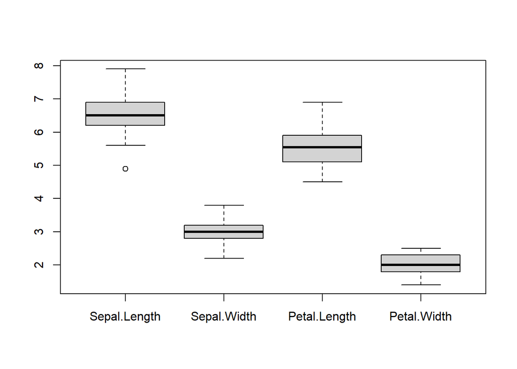

```r
inicio <- Sys.time()
a <- by(iris[-5], iris$Species, FUN=boxplot)
```

```r
tempo.apply <- Sys.time() - inicio
#esse a recebendo o by esconde as caracteristicas do boxplot que,
#por algum motivo, ele imprime quando se usa o by
```

**b. O pacote “vioplot” tem a função `vioplot` para construção de *violin plots* (verifique seu formato!). Construa *violin plots* de cada variável quantitativa do conjunto de dados, estratificando-a pelo fator `Species`. Remova todos os números do eixo x e usa a cor `“salmon”`.**

```r
library(vioplot)
```

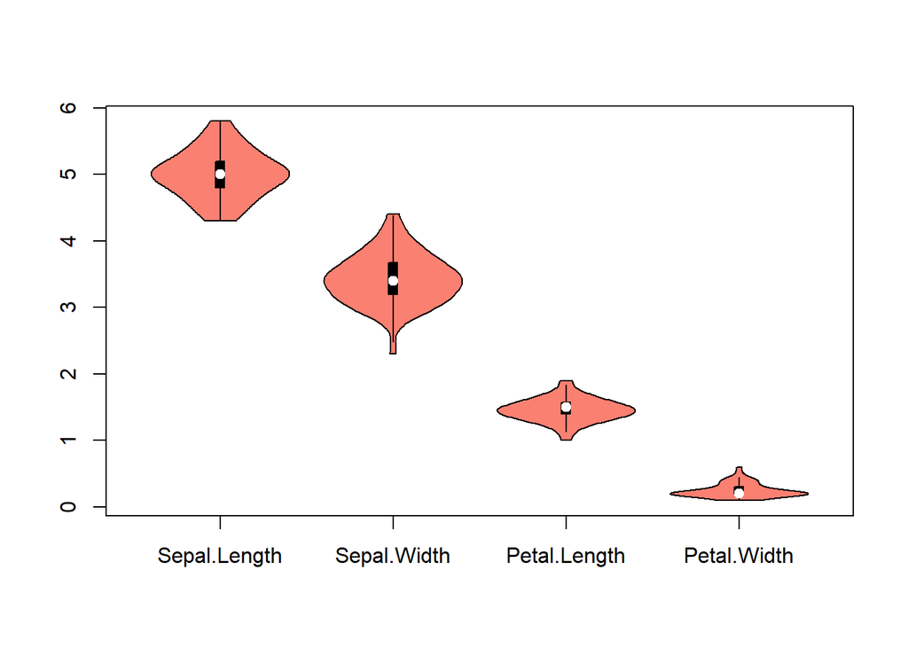

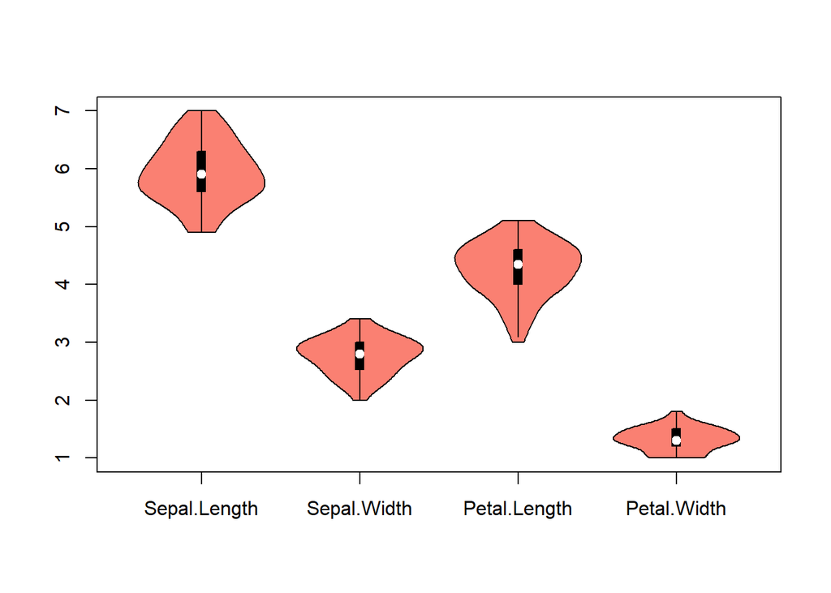

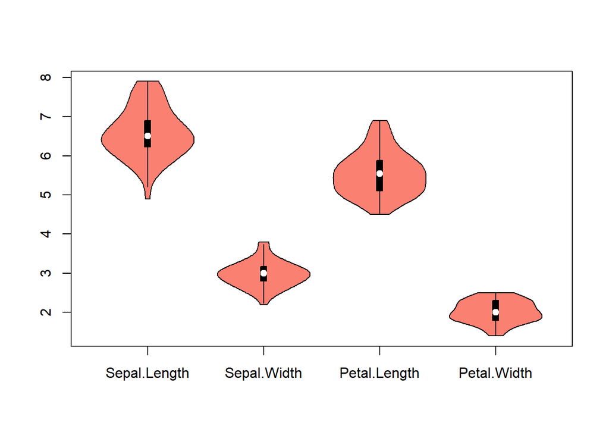

```r
inicio <- Sys.time()
a<-by(iris[-5], INDICES=iris$Species, FUN=vioplot,col="salmon",)
```

```r
tempo.apply <- tempo.apply + (Sys.time() - inicio)
```

**c. Repita o exercício usando estruturas de controle. Compare o tempo entre as duas abordagens (Estruturas de controle e família apply).**

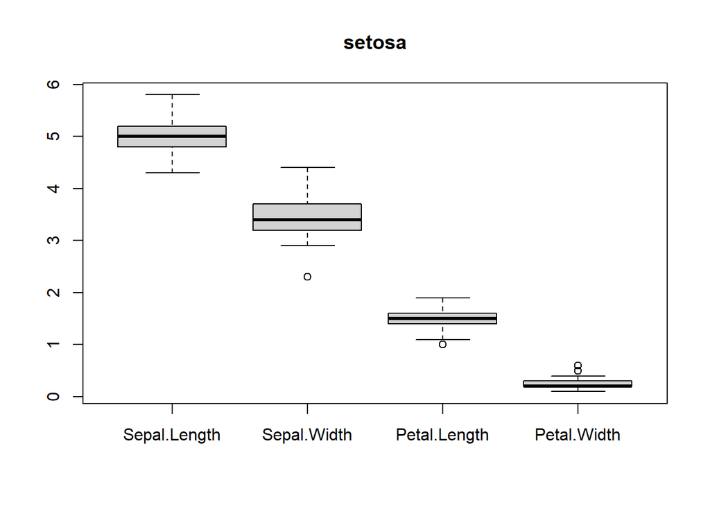

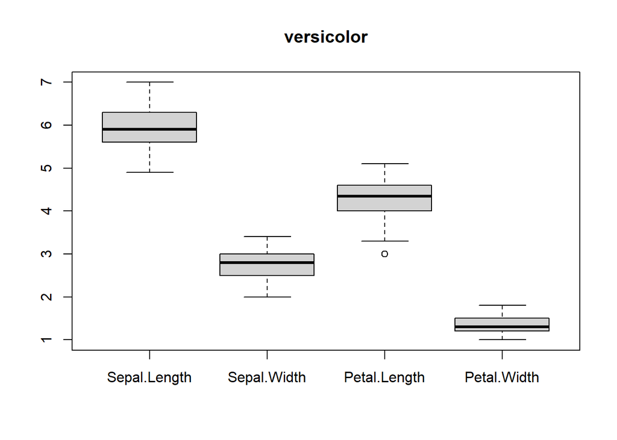

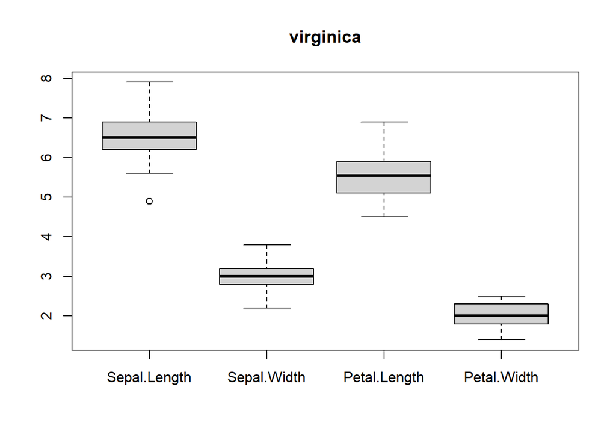

```r
inicio <- Sys.time()
#boxplot
for(i in unique(iris$Species)){
  boxplot(iris[iris$Species==i,-5], main=i)
}
```

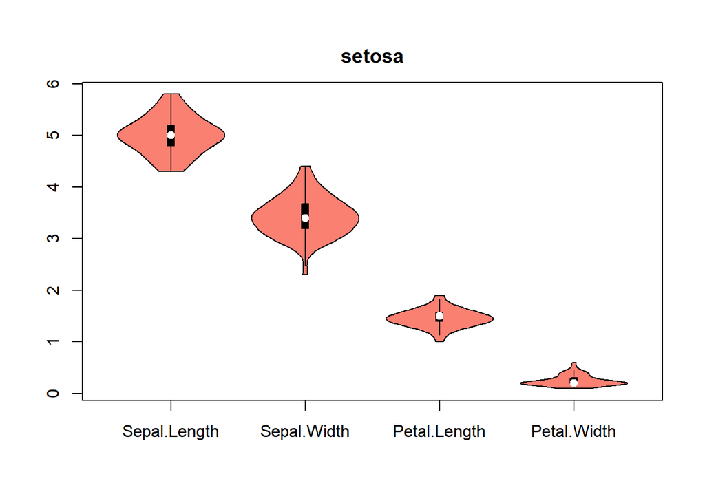

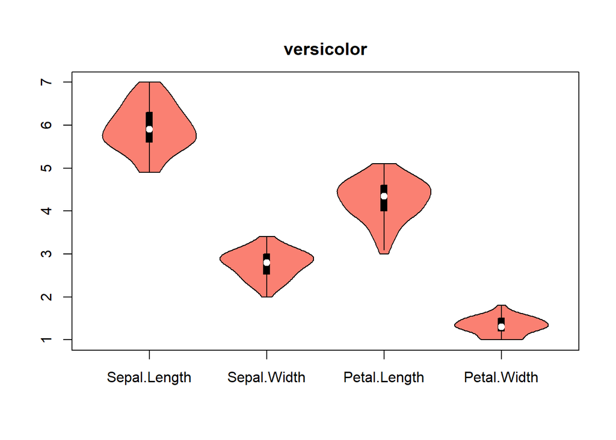

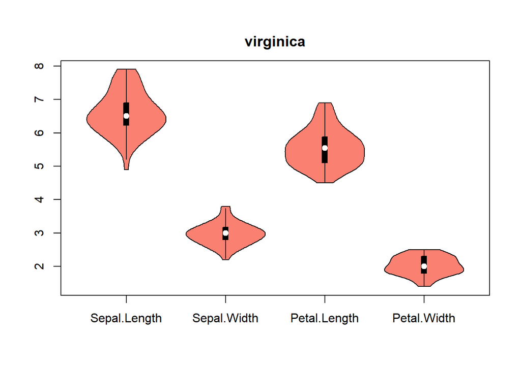

```r
#violin plot
for(i in unique(iris$Species)){
  vioplot(iris[iris$Species==i,-5], main=i, col="salmon")
}
```

```r
(Sys.time() - inicio) - tempo.apply
```

```
Time difference of 0.02062774 secs
```

## Questão 7

**a. Descubra qual das variáveis do conjunto de dados `iris` não é numérica.**

```r
inicio <- Sys.time()
nn<-!sapply(iris,FUN=is.numeric)
tempo.apply <- (Sys.time() - inicio)
```

**b. Identifique os níveis desse fator (utilize a função level).**

```r
levels(iris[,nn])
```

```
[1] "setosa"     "versicolor" "virginica"
```

**c. Ao invés disso, experimente a função unique e compare a saída**

```r
unique(iris[,nn])
```

```
[1] setosa     versicolor virginica
Levels: setosa versicolor virginica
```

**d. Repita o item (a) usando estruturas de controle. Compare o tempo entre as duas abordagens (Estruturas de controle e família apply).**

```r
inicio <- Sys.time()
for(i in 1:5){
  nn[i]<- !is.numeric(iris[,i])
}
(Sys.time() - inicio)-tempo.apply
```

```
Time difference of 0.002258778 secs
```

## Questão 8

```r
data(diamonds, package="ggplot2")
```

**a. Quais são as colunas de classe não numérica?**

```r
inicio <- Sys.time()
!sapply(diamonds,FUN=is.numeric)
```

```
  carat     cut   color clarity   depth   table   price       x       y       z
  FALSE    TRUE    TRUE    TRUE   FALSE   FALSE   FALSE   FALSE   FALSE   FALSE
```

```r
tempo.apply <- Sys.time() - inicio
```

**b. Obtenha a média das colunas 8, 9 e 10 das observações 10000 a 11000.**

```r
inicio <- Sys.time()
sapply(diamonds[10000:11000,c(8,9,10)],mean)
```

```
       x        y        z
6.237852 6.233506 3.851049
```

```r
tempo.apply <- (Sys.time() - inicio) + tempo.apply
```

**c. Repita (b), arredondando para um dígito.**

```r
medias <- round(sapply(diamonds[10000:11000,c(8,9,10)],mean),1)
```

**d. Ordene os resultados arredondados em ordem crescente.**

```r
sort(medias)
```

```
  z   x   y
3.9 6.2 6.2
```

**e. Repita o exercício usando estruturas de controle. Compare o tempo entre as duas abordagens (Estruturas de controle e família apply).**

```r
nn<- logical(0)
inicio <- Sys.time()
#variaveis nao numericas
for(i in 1:10){
  nn<-append(nn,!is.numeric(diamonds[,i]))
}
names(diamonds[,nn])
```

```
[1] "cut"     "color"   "clarity"
```

```r
#medias de x y e z nas linhas 10 mil a 1,1 mil
for(i in 8:10){
  print(mean(diamonds[10000:11000,i]))
}
```

```
[1] 6.237852
[1] 6.233506
[1] 3.851049
```

```r
(Sys.time()-inicio) - tempo.apply
```

```
Time difference of -0.01434922 secs
```

## Questão 9

**a. Calcule a mediana de cada coluna ordenada pelo número de carburadores. Use os argumentos padrão “x”, “by” e “FUN”. (`mtcars{datasets}`)**

```r
inicio<- Sys.time()
aggregate(x=mtcars[1:10], by=list(mtcars$carb), FUN=median)
```

```
  Group.1   mpg cyl   disp  hp  drat    wt   qsec  vs am gear
1       1 22.80   4 108.00  93 3.850 2.320 19.470 1.0  1  4.0
2       2 22.10   4 143.75 111 3.730 3.170 17.175 0.5  0  4.0
3       3 16.40   8 275.80 180 3.070 3.780 17.600 0.0  0  3.0
4       4 15.25   8 350.50 210 3.815 3.505 17.220 0.0  0  3.5
5       6 19.70   6 145.00 175 3.620 2.770 15.500 0.0  1  5.0
6       8 15.00   8 301.00 335 3.540 3.570 14.600 0.0  1  5.0
```

```r
tempo.apply<- Sys.time() - inicio
```

**b. Repita o item(a), usando a notação ‘formula’ como argumento.**

```r
aggregate(. ~ carb,data=mtcars, FUN=median)
```

```
  carb   mpg cyl   disp  hp  drat    wt   qsec  vs am gear
1    1 22.80   4 108.00  93 3.850 2.320 19.470 1.0  1  4.0
2    2 22.10   4 143.75 111 3.730 3.170 17.175 0.5  0  4.0
3    3 16.40   8 275.80 180 3.070 3.780 17.600 0.0  0  3.0
4    4 15.25   8 350.50 210 3.815 3.505 17.220 0.0  0  3.5
5    6 19.70   6 145.00 175 3.620 2.770 15.500 0.0  1  5.0
6    8 15.00   8 301.00 335 3.540 3.570 14.600 0.0  1  5.0
```

**c. Repita o item(a), usando estruturas de controle. Compare o tempo entre as duas abordagens (Estruturas de controle e família apply).**

```r
carbs <- sort(unique(mtcars$carb))
tabela <- matrix(ncol=10,nrow=6)
rownames(tabela)<- as.character(carbs)
colnames(tabela)<-names(mtcars)[-11]
inicio <- Sys.time()
for(i in 1:10){
  for(j in 1:6){
    tabela[j,i] <- median(mtcars[mtcars$carb==carbs[j],i])
  }
}
tabela
```

```
    mpg cyl   disp  hp  drat    wt   qsec  vs am gear
1 22.80   4 108.00  93 3.850 2.320 19.470 1.0  1  4.0
2 22.10   4 143.75 111 3.730 3.170 17.175 0.5  0  4.0
3 16.40   8 275.80 180 3.070 3.780 17.600 0.0  0  3.0
4 15.25   8 350.50 210 3.815 3.505 17.220 0.0  0  3.5
6 19.70   6 145.00 175 3.620 2.770 15.500 0.0  1  5.0
8 15.00   8 301.00 335 3.540 3.570 14.600 0.0  1  5.0
```

```r
(Sys.time() - inicio) - tempo.apply
```

```
Time difference of 0.00334096 secs
```

## Questão 10

**A função `system.time` retorna o tempo de operações em R. Verifique como esse comando funciona.**

**Para uma matriz X, 107 × 2 e um vetor y de comprimento 107 , calcule (algumas quantas vezes) o produto t(X)y, usando multiplicação de matrizes e a função crossproduct. Qual é o procedimento mais rápido?**

```r
X<- matrix(rnorm(214),ncol=2)
y<- rnorm(107)
t1<- function(n=1E20){
  system.time(t(X)%*%y)
}
#multiplicacao de matrizes do R
system.time(t1(),gcFirst = T)
```

```
  usuário   sistema decorrido
     0.04      0.00      0.05
```

```r
t2<- function(n=1E20){
  system.time(crossprod(X,y))
}
#funcao crossproduct
system.time(t2(),gcFirst = T)
```

```
  usuário   sistema decorrido
     0.05      0.00      0.04
```